# Notes on Atrial Fibrillation dataset analysis

João Miguel Alves

2023-02-10

## Introduction

The ATLAS score [[1]](https://pubmed.ncbi.nlm.nih.gov/29016770/) provides a risk estimate to predict the rate of Atrial Fibrillation (AF) recurrence after pulmonary vein isolation (PVI) procedure. However, it suffers from the typical limitations of clinical scores, such as the use of a small number of independent variables for the prediction of a single dependent variable, which remains unchanged throughout the patient’s clinical course.

The ATLAS score is based on 5 independent variables, being: Age, Sex, Smoking habits, Left atrial volume (LAV), and occurrence of paroxysmal AF. It is strongly dependent on the measurement of the LAV as its main driver, which is not always possible to obtain. Similarly to other clinical scores, it is unfeasible to be calculated in the absence of any of its predicting variables.

An additional limitation is that it establishes an upfront risk profile, which cannot be revised or readjusted during the patient’s subsequent follow-up. Also, other potential risk factors (as *eg.* Epicardial fat or Obstructive Sleep Apnea) are not taken into consideration for the calculation of this score.

This analysis proposes the structuring and fitting of a Bayesian Network (BN) that can represent medical knowledge on this field. This model can then be used to predict the occurrence of Atrial Fibrillation in patients, as an enhanced alternative to the ATLAS score.

## Dataset

```r
# Read dataset, as data frame
ds <- read.csv(file.path("data", "FA_dataset_pretreated.csv"),
               stringsAsFactors = TRUE) |> as.data.frame()

# Convert all logical variables to factors
ds[sapply(ds, is.logical)] <- lapply(ds[sapply(ds, is.logical)], as.factor)

# reorder factors' levels
ds$Age <- ordered(ds$Age, c("<=45", "46-65", "+65"))
ds$BMI <- ordered(ds$BMI, c("normal_weight", "overweight", "obese", "extreme_obese"))
ds$LeftAtrium_Vol <- ordered(ds$LeftAtrium_Vol, c("<100", "100-125", "+125"))
ds$EpiFat <- ordered(ds$EpiFat, c("<2.7", "2.7-4.6", "+4.6"))
```

The data set for this analysis consists in clinical data from 480 patients being followed at the Cardiac Arrhythmia Service of a public hospital in Portugal. It includes 12 categorical variables, with 1 observation per patient.

All patients underwent an ablation procedure to minimize the occurrence of Atrial Fibrillation (AF). The target outcome variable is `AF_relapse`, indicating whether or not a patient experienced an AF relapse after the ablation procedure.

**Dataset head**

```r
head(ds) |> knitr::kable()
```

| Sex | Age | BMI | Diabetes | HBP | Smoking_active | Alcohol | OSA | Persistent_AF | AF_relapse | LeftAtrium_Vol | EpiFat |
| --- | --- | --- | --- | --- | --- | --- | --- | --- | --- | --- | --- |
| male | 46-65 | normal_weight | FALSE | TRUE | FALSE | FALSE | FALSE | Paroxysmal | FALSE | 100-125 | <2.7 |
| male | 46-65 | overweight | FALSE | FALSE | FALSE | FALSE | FALSE | Paroxysmal | FALSE | 100-125 | 2.7-4.6 |
| male | 46-65 | obese | TRUE | FALSE | FALSE | FALSE | TRUE | Paroxysmal | TRUE | +125 | +4.6 |
| male | <=45 | overweight | FALSE | FALSE | FALSE | FALSE | FALSE | Paroxysmal | FALSE | 100-125 | 2.7-4.6 |
| female | 46-65 | overweight | FALSE | FALSE | FALSE | FALSE | FALSE | Paroxysmal | FALSE | 100-125 | 2.7-4.6 |
| male | +65 | overweight | FALSE | FALSE | FALSE | FALSE | FALSE | Paroxysmal | TRUE | +125 | +4.6 |

**Dataset structure**

```r
summary(ds)
```

```
##      Sex         Age                 BMI       Diabetes      HBP
##  female:185   <=45 : 57   normal_weight: 95   FALSE:434   FALSE:188
##  male  :295   46-65:234   overweight   :230   TRUE : 46   TRUE :292
##               +65  :189   obese        :122
##                           extreme_obese: 33
##  Smoking_active  Alcohol       OSA         Persistent_AF AF_relapse
##  FALSE:345      FALSE:455   FALSE:430   Paroxysmal:374   FALSE:314
##  TRUE :135      TRUE : 25   TRUE : 50   Persistent:106   TRUE :166
##
##
##  LeftAtrium_Vol     EpiFat
##  <100   :163    <2.7   :160
##  100-125:175    2.7-4.6:161
##  +125   :142    +4.6   :159
##
```

## Network structure

The structure of the Bayesian network was built based on expert knowledge as well as inference from data.

### White list

On the expert knowledge side, we opted to associate the diseases tracked on the dataset with their known risk factors. This knowledge is include as a **whitelist**, the list of relations to be present in the network structure. Risk factors were included for Diabetes, High Blood Pressure (HBP) and Obstructive Sleep Apnea (OSA).

Additionally,for this whitelist, we included all 5 predictive variables for AF relapse, previously identified for the ATLAS score. On top of these, 2 other variables were included as potential risk factors for the same outcome, as suggested by medical literature: Epicardial fat (EpiFat) [[2]](https://academic.oup.com/europace/article/24/8/1201/6546753) [[3]](https://onlinelibrary.wiley.com/doi/10.1111/pace.13825) [[4]](https://academic.oup.com/eurheartj/article/38/17/1294/3056898) [[5]](https://onlinelibrary.wiley.com/doi/abs/10.1111/obr.13277) and Obstructive Sleep Apnea (OSA) [[6]](https://www.ahajournals.org/doi/full/10.1161/JAHA.121.022560) [[7]](https://pubmed.ncbi.nlm.nih.gov/33516410/) [[8]](https://jamanetwork.com/journals/jamacardiology/article-abstract/2674722)

```r
dag_white_list <- as.data.frame(tibble::tribble(
  #--------------- |-----------
  ~from,            ~to,
  #--- Diabetes risk-factors
  "Age",            "Diabetes",
  "Sex",            "Diabetes",
  "BMI",            "Diabetes",
  #--- High Blood Pressure risk-factors
  "Age",            "HBP",
  "Sex",            "HBP",
  "Alcohol",        "HBP",
  "Smoking_active", "HBP",
  "BMI",            "HBP",
  "Diabetes",       "HBP",
  #--- OSA risk-factors
  "Age",            "OSA",
  "BMI",            "OSA",
  "HBP",            "OSA",
  "Smoking_active", "OSA",
  "Sex",            "OSA",
  # "Diabetes",     "OSA", # There is a correlation, but the direction is not clear
  #--- ATLAS related
  "Age",            "AF_relapse",
  "Sex",            "AF_relapse",
  "LeftAtrium_Vol", "AF_relapse",
  "Smoking_active", "AF_relapse",
  "Persistent_AF",  "AF_relapse",
  #--- Other expert knowledge
  "EpiFat",         "AF_relapse",
  "OSA",            "AF_relapse",
))
```

### Black list

As **blacklist**, we assumed any arcs directed to `Age` or `Sex` as to be avoided. These variables are independent of any other, and therefore should not receive any directed arc.

```r
features_all <- names(ds)
bl_01 <- data.frame(from = features_all[features_all != "Age"], to = "Age")
bl_02 <- data.frame(from = features_all[features_all != "Sex"], to = "Sex")
dag_black_list <- rbind(bl_01, bl_02)
```

Additional arcs here left to be discovered by a “hill‑climbing” algorithm.

```r
dag <- bnlearn::hc(ds,
                   whitelist = dag_white_list,
                   blacklist = dag_black_list)
```

### Plot structure

The network structure is presented in the figure below. (for 480 patients)

Colored nodes indicate:

- `[grey]` : Whitelisted diseases with attributed risk factors (`Diabetes`, `HBP`, `OSA`)
- `[sand]` : ATLAS’ 5 predictive variables (`Age`, `Sex`, `Smoking_active`, `LeftAtrium_Vol`, `Persistent_AF`)
- `[blue]` : Outcome variable (`AF_Relapse`)

Light grey arcs indicate whitelisted relations, *ie.* known risk factors. Orange colored arcs indicate relations discovered by the hill‑climbing algorithm, suggesting meaningful relations between variables.

Note than `OSA`, `Persistent_AF` and `LeftAtrium_Vol` were set to be directly linked to `AF_relapse` (whitelisted). Interestingly, the model also suggests other links not previously whitelisted:

- `BMI` —> `EpiFat`
- `OSA` —> `Persistent_AF`
- `Persistent_AF` —> `LeftAtrium_vol`

All these relation are supported by medical literature, hence providing a reasonable representation of clinical knowledge in this field.

Regarding the outcome variable `AF_relapse`, the model did not find any other relevant link apart from those previously whitelisted.

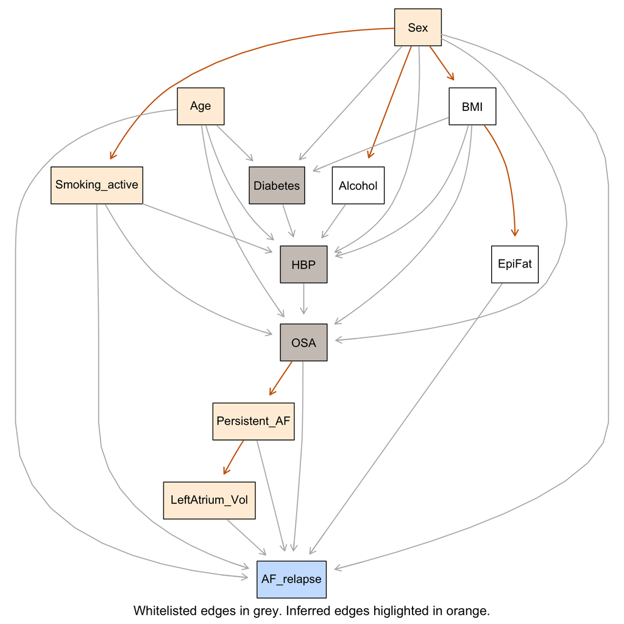

```r
gr <- graphviz.plot(dag,
                    groups = NULL,
                    sub = paste0("Whitelisted edges in grey. Inferred edges higlighted in orange."),
                    layout = "dot",
                    shape = "rectangle",
                    render = FALSE)

# Highlight specific nodes ~~~~~~~
node.attrs <- nodeRenderInfo(gr)
#... Diseases with attributed risk factors
node.attrs$fill[c("Diabetes",
                  "HBP",
                  "OSA")] <- "seashell3"
#... ATLAS risk factors
node.attrs$fill[c("Sex",
                  "Age",
                  "Smoking_active",
                  "LeftAtrium_Vol",
                  "Persistent_AF")] <- "antiquewhite1"
#... Outcome
node.attrs$fill[c("AF_relapse")] <- "lightsteelblue1"


# Highlight specific edges ~~~~~~~
edge.attrs <- edgeRenderInfo(gr)
#... Highlight Whitelist
wl <- paste(dag_white_list$from, dag_white_list$to, sep = "~")
edge.attrs$col[names(edge.attrs$col) %in% wl] <- "grey70"
edge.attrs$lwd[names(edge.attrs$col) %in% wl] <- 1.2
#... Highlight edges discovered by model (not in whitelist)
edge.attrs$col[!(names(edge.attrs$col) %in% wl)] <- "darkorange3"
edge.attrs$lwd[!(names(edge.attrs$col) %in% wl)] <- 1.5

#-- Set new attributes to graphic object
nodeRenderInfo(gr) <- node.attrs
edgeRenderInfo(gr) <- edge.attrs
renderGraph(gr)
```

An alternative representation of the Bayesian Network showing class frequencies at each node.

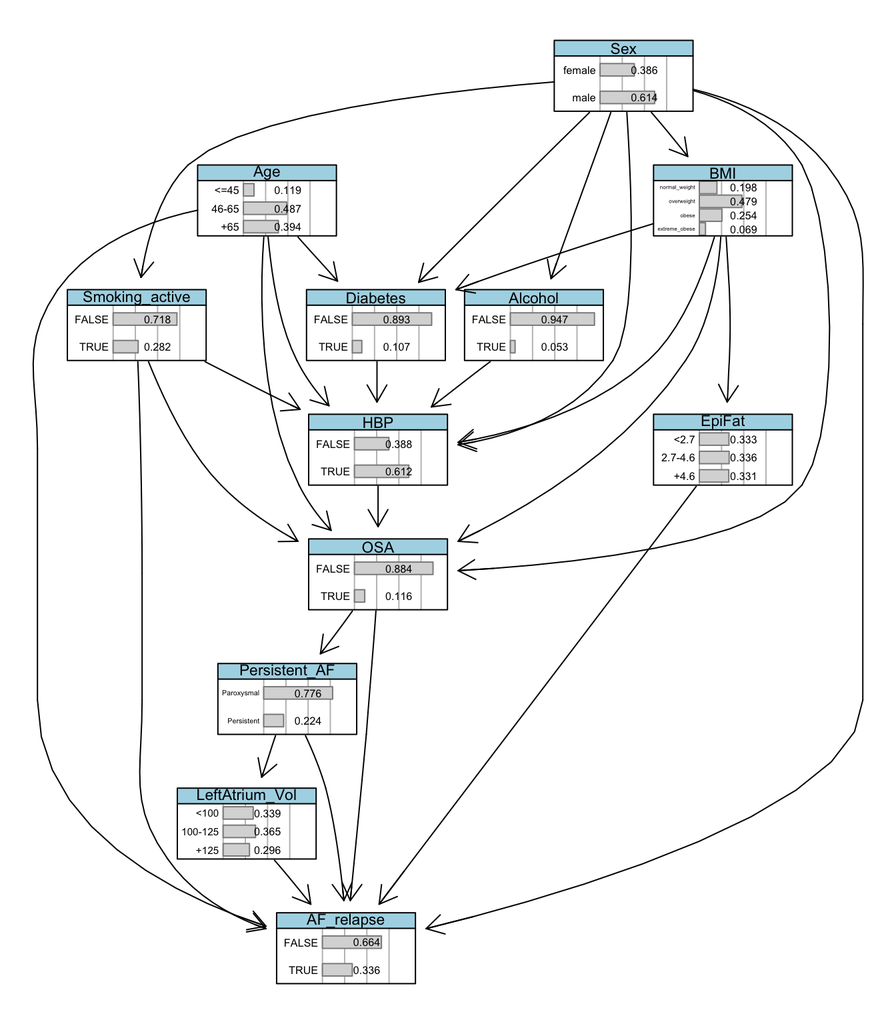

```r
bnlearn::graphviz.chart(bn.fit(dag, data = ds, method = "bayes"),
                        type = "barprob",
                        layout = "dot",
                        draw.labels = TRUE,
                        grid = TRUE,
                        scale = c(0.8, 1.8),
                        strip.bg = "lightblue",
                        bar.col = "grey40")
```

## Model training

```r
# Define experiment parameters
seed <- 811
n_tries <- 20
```

### Generate synthetic data

We generate synthetic data by simulating random samples based on the learnt Bayesian network structure and the original dataset. This synthetic data will be used to train the model. Model performance will then be tested on the real (original) dataset.

For this experiment, we generate synthetic data from 100 bootstrap samples, for a total of 48000 observations.

```r
# Train subset: synthetic data
n <- nrow(ds)
ds_train <- data.frame(matrix(nrow = 0, ncol = length(ds)))
names(ds_train) <- names(ds)
set.seed(seed)
for (i in 1:100) {
  ds_train <-
    rbind(ds_train,
          bnlearn::rbn(x = dag,
                       n = n,
                       data = ds[sample(1:n, n, replace = TRUE), ],
                       fit = "bayes"))
}

# Test subset: original data
ds_test <- ds
```

### Learn model

The model was set to learn the conditional probabilities between features on the train set, based on the previously learnt network structure. Conditional probabilities were calculated by a classic Bayesian posterior estimator (`method = bayes`).

```r
fit.bayes <- bn.fit(dag, data = ds_train, method = "bayes", iss = 10)
```

## Testing all parent nodes

### Calculate relapse probabilities

For this step, we calculated the conditional probability of `AF relapse` for each patient at the test set, considering their current clinical conditions. The calculation considered the clinical state for all `AF_relapse` parent nodes: `Age`, `Sex`, `Smoking_active`, `Persistent_AF`, `LeftAtrium_Vol`, `EpiFat` and `OSA`.

```r
# Get parent nodes for "AF_relapse" from model
parent_nodes <-
  bnlearn::arcs(dag) %>%
  as.data.frame() %>%
  dplyr::filter(to == "AF_relapse") %>%
  dplyr::select(from) %>%
  unlist() %>%
  unname()

# Create new column for computed relapse probabilities
ds_test[, "Relapse_prob_pred7"] <- NA

# Calculate probabilities in test set
calc <- mclapply(matrix(1:nrow(ds_test)), function(i){
  evidence_patient <<- as.data.frame(ds_test[i, parent_nodes])

  calc <- sapply(matrix(NA, n_tries), FUN = function(x) {
    bnlearn::cpquery(fitted = fit.bayes,
                     event = (AF_relapse == TRUE),
                     evidence = ((Sex == evidence_patient$Sex) &
                                   (Age == evidence_patient$Age) &
                                   (Smoking_active == evidence_patient$Smoking_active) &
                                   (Persistent_AF == evidence_patient$Persistent_AF) &
                                   (LeftAtrium_Vol == evidence_patient$LeftAtrium_Vol) &
                                   (EpiFat == evidence_patient$EpiFat) &
                                   (OSA == evidence_patient$OSA))
    )}) |> mean(na.rm = TRUE)

  return(calc)
}, mc.cores = cores)
ds_test$Relapse_prob_pred7 <- unlist(calc)
```

### Evaluate performance

```r
model_roc_pred7 <- pROC::roc(ds_test$AF_relapse, ds_test$Relapse_prob_pred7)
model_cutoff_pred7 <- coords(model_roc_pred7, x = "best", ret = "threshold") |> unlist() |> unname()
```

Model’s performance for classifying AF relapse with all parent nodes (7 predictors) was evaluated through the Area Under the ROC curve, with a computed AUC value of 0.923. The best cut‑off value for this classification was calculated at 0.355.

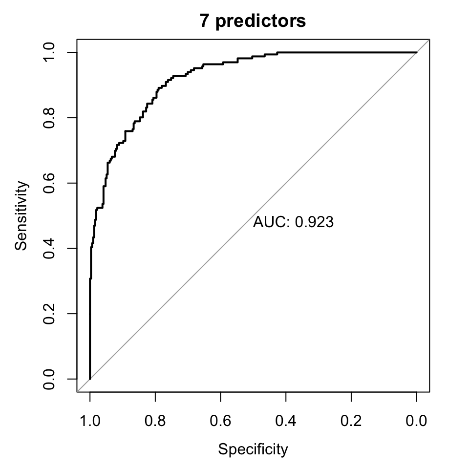

```r
ds_test$prediction_pred7 <- ifelse(ds_test$Relapse_prob_pred7 < model_cutoff_pred7,
                             levels(ds_test$AF_relapse)[1],
                             levels(ds_test$AF_relapse)[2]) |> factor()
cm_pred7 <- caret::confusionMatrix(data = ds_test$prediction_pred7,
                             reference = ds_test$AF_relapse,
                             positive = "TRUE")
print(cm_pred7)
```

```
## Confusion Matrix and Statistics
##
##           Reference
## Prediction FALSE TRUE
##      FALSE   248   18
##      TRUE     66  148
##
##                Accuracy : 0.825
##                  95% CI : (0.788, 0.8579)
##     No Information Rate : 0.6542
##     P-Value [Acc > NIR] : < 2.2e-16
##
##                   Kappa : 0.6379
##
##  Mcnemar's Test P-Value : 2.926e-07
##
##             Sensitivity : 0.8916
##             Specificity : 0.7898
##          Pos Pred Value : 0.6916
##          Neg Pred Value : 0.9323
##              Prevalence : 0.3458
##          Detection Rate : 0.3083
##    Detection Prevalence : 0.4458
##       Balanced Accuracy : 0.8407
##
##        'Positive' Class : TRUE
##
```

For the calculated cut‑off value of 0.355, the model shows an accuracy of 0.825, a sensitivity of 0.892 and a specificity of 0.790.

The figure below presents a dotplot exhibiting the estimated probabilities of AF relapse for all patients in the test set. Dots are split according to reported occurrence of AF relapse for those patients. The dashed horizontal line shows the calculated cut‑off value.

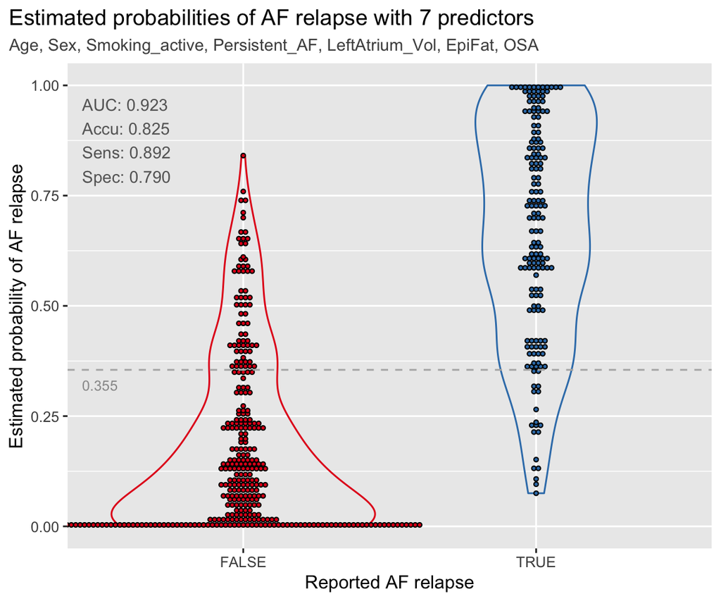

```r
model_metrics_pred7 <- paste0(
  "AUC: ",  sprintf("%.3f", model_roc_pred7$auc), "\n",
  "Accu: ", sprintf("%.3f", cm_pred7$overall["Accuracy"]), "\n",
  "Sens: ", sprintf("%.3f", cm_pred7$byClass["Sensitivity"]), "\n",
  "Spec: ", sprintf("%.3f", cm_pred7$byClass["Specificity"]))

dotplot_pred7 <-
  ggplot(data = ds_test, aes(x = AF_relapse,
                             y = Relapse_prob_pred7)) +
  ylim(0, 1) +
  geom_violin(aes(color = AF_relapse),
              fill = "transparent") +
  geom_dotplot(aes(fill = AF_relapse),
               binaxis = "y",
               binwidth = 0.01,
               stackdir = "center") +
  scale_fill_brewer(palette = "Set1") +
  scale_color_brewer(palette = "Set1") +
  labs(title = "Estimated probabilities of AF relapse with 7 predictors",
       subtitle = "Age, Sex, Smoking_active, Persistent_AF, LeftAtrium_Vol, EpiFat, OSA") +
  xlab("Reported AF relapse") +
  ylab("Estimated probability of AF relapse") +
  theme(plot.title.position = "plot",
        plot.subtitle = element_text(color = "grey30", size = 10),
        legend.position = "none") +
  geom_hline(yintercept = model_cutoff_pred7,
             linetype = "dashed",
             color = "grey70") +
  annotate(geom = "text",
           x = 0.45,
           y = model_cutoff_pred7,
           size = 3,
           label = round(model_cutoff_pred7, 3),
           color = "grey60",
           hjust = 0,
           vjust = 2) +
  annotate(geom = "text",
           x = 0.45,
           y = 0.97,
           size = 3.5,
           label = model_metrics_pred7,
           color = "grey40",
           hjust = 0,
           vjust = 1)

dotplot_pred7
```

## Testing 5 predictors

From the 7 predictive features used in the previous calculation, 2 are usually difficult to obtain: `LeftAtrial_Vol` and `EpiFat`. These 2 features are calculated by diagnostic imaging, which is not always performed for all patients. In some cases, the physician does not have access to those measurements, which impairs the calculation of medical scores that require any of those values (*eg.* the ATLAS score).

This next test aims to evaluate the model’s performance without those 2 features, hence simulating a frequent real‑life scenario.

### Calculate relapse probabilities

For this step, we calculated the conditional probability of `AF relapse` for each patient at the test set, considering only 5 of its parent nodes: `Age`, `Sex`, `Smoking_active`, `Persistent_AF`, and `OSA`. The remaining 2 parent nodes `LeftAtrium_Vol` and `EpiFat` were disregard from evidence for the calculation of the conditional probabilities.

```r
# Create new column for computed relapse probabilities
ds_test[, "Relapse_prob_pred5"] <- NA

# Calculate probabilities in test set
calc <- mclapply(matrix(1:nrow(ds_test)), function(i){
  evidence_patient <<- as.data.frame(ds_test[i, parent_nodes])

  calc <- sapply(matrix(NA, n_tries), FUN = function(x) {
    bnlearn::cpquery(fitted = fit.bayes,
                     event = (AF_relapse == TRUE),
                     evidence = ((Sex == evidence_patient$Sex) &
                                   (Age == evidence_patient$Age) &
                                   (Smoking_active == evidence_patient$Smoking_active) &
                                   (Persistent_AF == evidence_patient$Persistent_AF) &
                                   # (LeftAtrium_Vol == evidence_patient$LeftAtrium_Vol) &
                                   # (EpiFat == evidence_patient$EpiFat) &
                                   (OSA == evidence_patient$OSA))
    )}) |> mean(na.rm = TRUE)

  return(calc)
}, mc.cores = cores)
ds_test$Relapse_prob_pred5 <- unlist(calc)
```

### Evaluate performance

```r
model_roc_pred5 <- pROC::roc(ds_test$AF_relapse, ds_test$Relapse_prob_pred5)
model_cutoff_pred5 <- coords(model_roc_pred5, x = "best", ret = "threshold") |> unlist() |> unname()
```

As previously, model’s performance for classifying AF relapse was evaluated through the Area Under the ROC curve with a computed AUC value of 0.728. The best cut‑off value for this classification was calculated at 0.341.

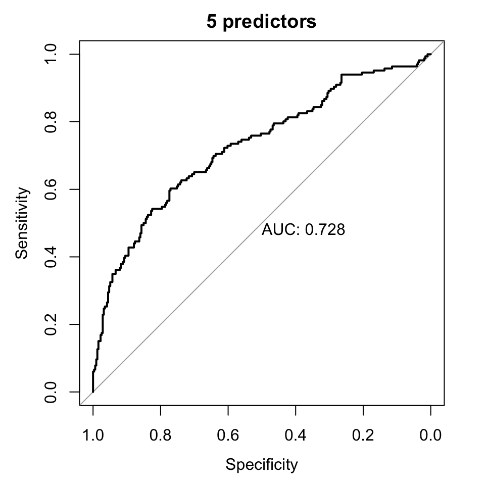

```r
ds_test$prediction_pred5 <- ifelse(ds_test$Relapse_prob_pred5 < model_cutoff_pred5,
                             levels(ds_test$AF_relapse)[1],
                             levels(ds_test$AF_relapse)[2]) |> factor()
cm_pred5 <- caret::confusionMatrix(data = ds_test$prediction_pred5,
                             reference = ds_test$AF_relapse,
                             positive = "TRUE")
print(cm_pred5)
```

```
## Confusion Matrix and Statistics
##
##           Reference
## Prediction FALSE TRUE
##      FALSE   242   66
##      TRUE     72  100
##
##                Accuracy : 0.7125
##                  95% CI : (0.6697, 0.7526)
##     No Information Rate : 0.6542
##     P-Value [Acc > NIR] : 0.003765
##
##                   Kappa : 0.37
##
##  Mcnemar's Test P-Value : 0.670379
##
##             Sensitivity : 0.6024
##             Specificity : 0.7707
##          Pos Pred Value : 0.5814
##          Neg Pred Value : 0.7857
##              Prevalence : 0.3458
##          Detection Rate : 0.2083
##    Detection Prevalence : 0.3583
##       Balanced Accuracy : 0.6866
##
##        'Positive' Class : TRUE
##
```

For the calculated cut‑off value of 0.341, the model shows an accuracy of 0.713, a sensitivity of 0.602 and a specificity of 0.771.

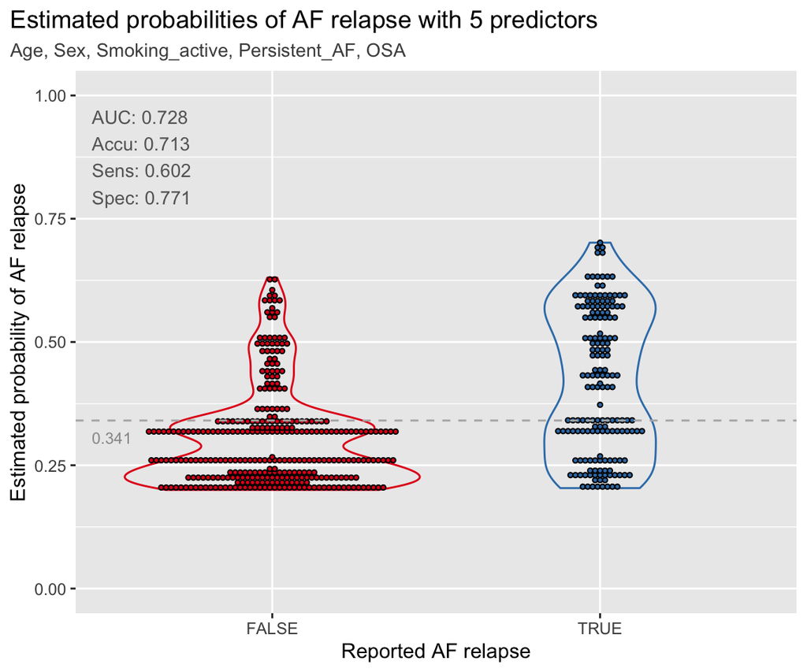

```r
  model_metrics_pred5 <- paste0(
    "AUC: ",  sprintf("%.3f", model_roc_pred5$auc), "\n",
    "Accu: ", sprintf("%.3f", cm_pred5$overall["Accuracy"]), "\n",
    "Sens: ", sprintf("%.3f", cm_pred5$byClass["Sensitivity"]), "\n",
    "Spec: ", sprintf("%.3f", cm_pred5$byClass["Specificity"]))

  dotplot_pred5 <-
    ggplot(data = ds_test, aes(x = AF_relapse,
                               y = Relapse_prob_pred5)) +
    ylim(0, 1) +
    geom_violin(aes(color = AF_relapse),
                fill = "transparent") +
    geom_dotplot(aes(fill = AF_relapse),
                 binaxis = "y",
                 binwidth = 0.01,
                 stackdir = "center") +
    scale_fill_brewer(palette = "Set1") +
    scale_color_brewer(palette = "Set1") +
    labs(title = "Estimated probabilities of AF relapse with 5 predictors",
         subtitle = "Age, Sex, Smoking_active, Persistent_AF, OSA") +
    xlab("Reported AF relapse") +
    ylab("Estimated probability of AF relapse") +
    theme(plot.title.position = "plot",
          plot.subtitle = element_text(color = "grey30", size = 10),
          legend.position = "none") +
    geom_hline(yintercept = model_cutoff_pred5,
               linetype = "dashed",
               color = "grey70") +
    annotate(geom = "text",
             x = 0.45,
             y = model_cutoff_pred5,
             size = 3,
             label = round(model_cutoff_pred5, 3),
             color = "grey60",
             hjust = 0,
             vjust = 2) +
    annotate(geom = "text",
             x = 0.45,
             y = 0.97,
             size = 3.5,
             label = model_metrics_pred5,
             color = "grey40",
             hjust = 0,
             vjust = 1)

  dotplot_pred5
```

## Testing 6 predictors

According to the previously defined bayesian network structure, the node `EpiFat` has as single parent `BMI`, meaning that the latter directly influences the former. As such, the absence of information on `EpiFat` for a given patient can be partially compensated by its information on `BMI` value. This possibility gains relevance when observed that Body Mass Index is usually an available or easy to obtain feature for any patient.

This next experiment tests the predicting power of the model when using the 5 predictors in the last experient, plus `BMI`. All these 6 features (`Age`, `Sex`, `Smoking_active`, `Persistent_AF`, `OSA`, and `BMI`) are clinical variables which are usually available for physicians’ evaluation without the need for using other additional complex or expensive diagnosis means.

### Calculate relapse probabilities

For this step, we calculated the conditional probability of `AF relapse` for each patient at the test set, considering only 5 of its parent nodes: `Age`, `Sex`, `Smoking_active`, `Persistent_AF`, `OSA` and `BMI`. The absence of information on `EpiFat` node is compensated by evidence on `BMI` for the calculation of the conditional probabilities. For the purpose of this test, any information on `LeftAtrium_Vol` and `EpiFat` were disregard.

```r
# Create new column for computed relapse probabilities
ds_test[, "Relapse_prob_pred6"] <- NA

# Calculate probabilities in test set
calc <- mclapply(matrix(1:nrow(ds_test)), function(i){
  evidence_patient <<- as.data.frame(ds_test[i, c(parent_nodes, "BMI")])

  calc <- sapply(matrix(NA, n_tries), FUN = function(x) {
    bnlearn::cpquery(fitted = fit.bayes,
                     event = (AF_relapse == TRUE),
                     evidence = ((Sex == evidence_patient$Sex) &
                                   (Age == evidence_patient$Age) &
                                   (Smoking_active == evidence_patient$Smoking_active) &
                                   (Persistent_AF == evidence_patient$Persistent_AF) &
                                   # (LeftAtrium_Vol == evidence_patient$LeftAtrium_Vol) &
                                   # (EpiFat == evidence_patient$EpiFat) &
                                   (OSA == evidence_patient$OSA) &
                                   (BMI == evidence_patient$BMI))
    )}) |> mean(na.rm = TRUE)

  return(calc)
}, mc.cores = cores)
ds_test$Relapse_prob_pred6 <- unlist(calc)
```

### Evaluate performance

```r
model_roc_pred6 <- pROC::roc(ds_test$AF_relapse, ds_test$Relapse_prob_pred6)
model_cutoff_pred6 <- coords(model_roc_pred6, x = "best", ret = "threshold") |> unlist() |> unname()
```

Model’s performance for classifying AF relapse was evaluated through the Area Under the ROC curve with a computed AUC value of 0.745. The best cut‑off value for this classification was calculated at 0.389.

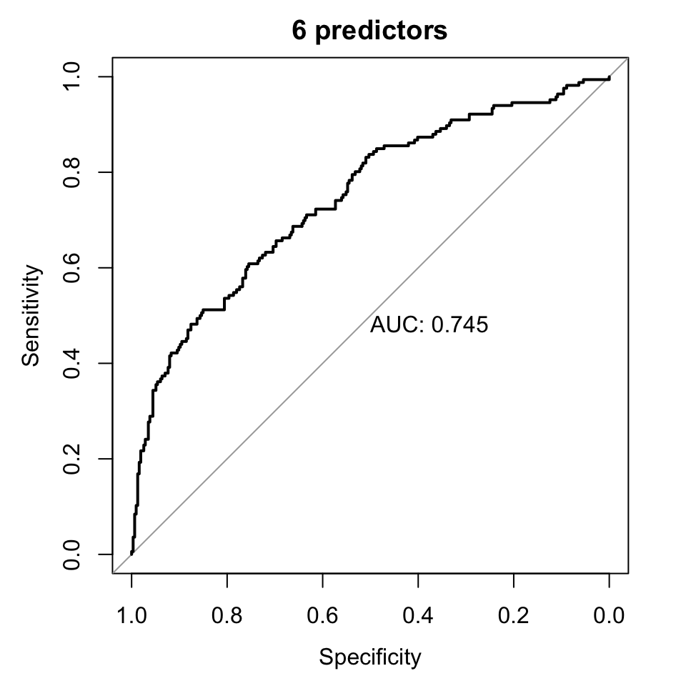

```r
ds_test$prediction_pred6 <- ifelse(ds_test$Relapse_prob_pred6 < model_cutoff_pred6,
                             levels(ds_test$AF_relapse)[1],
                             levels(ds_test$AF_relapse)[2]) |> factor()
cm_pred6 <- caret::confusionMatrix(data = ds_test$prediction_pred6,
                             reference = ds_test$AF_relapse,
                             positive = "TRUE")
print(cm_pred6)
```

```
## Confusion Matrix and Statistics
##
##           Reference
## Prediction FALSE TRUE
##      FALSE   237   65
##      TRUE     77  101
##
##                Accuracy : 0.7042
##                  95% CI : (0.6611, 0.7447)
##     No Information Rate : 0.6542
##     P-Value [Acc > NIR] : 0.01137
##
##                   Kappa : 0.3571
##
##  Mcnemar's Test P-Value : 0.35596
##
##             Sensitivity : 0.6084
##             Specificity : 0.7548
##          Pos Pred Value : 0.5674
##          Neg Pred Value : 0.7848
##              Prevalence : 0.3458
##          Detection Rate : 0.2104
##    Detection Prevalence : 0.3708
##       Balanced Accuracy : 0.6816
##
##        'Positive' Class : TRUE
##
```

For the calculated cut‑off value of 0.389, the model shows an accuracy of 0.704, a sensitivity of 0.608 and a specificity of 0.755.

These results represent a slight performance from the previous test with 5 predictor (0.728), hence showing that the absence of patient’s information about `EpiFat` can be partially compensated by evidence on `BMI`. This improvement is, however, modest.

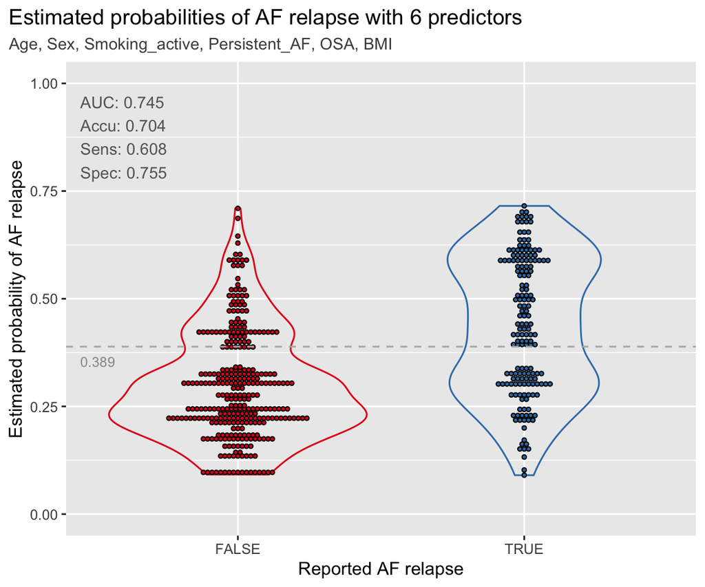

```r
  model_metrics_pred6 <- paste0(
    "AUC: ",  sprintf("%.3f", model_roc_pred6$auc), "\n",
    "Accu: ", sprintf("%.3f", cm_pred6$overall["Accuracy"]), "\n",
    "Sens: ", sprintf("%.3f", cm_pred6$byClass["Sensitivity"]), "\n",
    "Spec: ", sprintf("%.3f", cm_pred6$byClass["Specificity"]))

  dotplot_pred6 <-
    ggplot(data = ds_test, aes(x = AF_relapse,
                               y = Relapse_prob_pred6)) +
    ylim(0, 1) +
    geom_violin(aes(color = AF_relapse),
                fill = "transparent") +
    geom_dotplot(aes(fill = AF_relapse),
                 binaxis = "y",
                 binwidth = 0.01,
                 stackdir = "center") +
    scale_fill_brewer(palette = "Set1") +
    scale_color_brewer(palette = "Set1") +
    labs(title = "Estimated probabilities of AF relapse with 6 predictors",
         subtitle = "Age, Sex, Smoking_active, Persistent_AF, OSA, BMI") +
    xlab("Reported AF relapse") +
    ylab("Estimated probability of AF relapse") +
    theme(plot.title.position = "plot",
          plot.subtitle = element_text(color = "grey30", size = 10),
          legend.position = "none") +
    geom_hline(yintercept = model_cutoff_pred6,
               linetype = "dashed",
               color = "grey70") +
    annotate(geom = "text",
             x = 0.45,
             y = model_cutoff_pred6,
             size = 3,
             label = round(model_cutoff_pred6, 3),
             color = "grey60",
             hjust = 0,
             vjust = 2) +
    annotate(geom = "text",
             x = 0.45,
             y = 0.97,
             size = 3.5,
             label = model_metrics_pred6,
             color = "grey40",
             hjust = 0,
             vjust = 1)

  dotplot_pred6
```

## Discussion

The model based on a Bayesian Network, built from both expert knowledge and data inference, shows a good discriminatory power for predicting the relapse of Atrial Fibrillation (AF) in patients after surgical ablation. When using evidence from all the parent nodes of our outcome variable, the model performs with a computed AUC value of 0.923.

In the absence of information on `LeftAtrial_Vol` and `EpiFat` as predictive features, the model shows a reasonable performance with a computed AUC value of 0.728. This simulation is particularly relevant, as those 2 predictive features are not always accessible to physicians for the calculation of relapse risk by using medical scores.

The absence of `EpiFat` can be partially compensated by evidence from `BMI`, as this is its parent node. Considering clinical practice, this poses an interesting possibility, as values for Body Mass Index are usually available for clinical evaluation on most patients. However, the improvement in performance is not highly expressive, with AUC increasing only slightly from 0.728 to 0.745.

This model can be regarded as an enhancement of the ATLAS score, as it is based on its 5 predicting features, to which 2 other additional features were added. The Bayesian Network model has as advantages i) the possibility of being calculated even in cases of incomplete information (*eg.* when there is no information about the Left atrial volume), and 2) the possibility of being continuously retrained as new patient information is added to the model, hence expectably providing more accurate results as new evidence is included in the calculation.

**Additional comments:**

- `EpiFat` and `LeftAtrial_Vol` account for approximately 50% of the predicting power of the model *(experiment not shown in this report)*. The absence of these 2 predictors strongly reduces its predictive power.

## References

[1] Mesquita J, Ferreira AM, Cavaco D, et al. *Development and validation of a risk score for predicting atrial fibrillation recurrence after a first catheter ablation procedure - ATLAS score*. Europace. 2018;20(FI_3):f428-f435. doi:10.1093/europace/eux265

[2] Poggi AL, Gaborit B, Schindler TH, Liberale L, Montecucco F, Carbone F. *Epicardial fat and atrial fibrillation: the perils of atrial failure*. Europace. 2022;24(8):1201-1212. doi:10.1093/europace/euac015

[3] Zhou M, Wang H, Chen J, Zhao L. *Epicardial adipose tissue and atrial fibrillation: Possible mechanisms, potential therapies, and future directions*. Pacing Clin Electrophysiol. 2020;43(1):133-145. doi:10.1111/pace.13825

[4] Wong CX, Ganesan AN, Selvanayagam JB. *Epicardial fat and atrial fibrillation: current evidence, potential mechanisms, clinical implications, and future directions*. Eur Heart J. 2017;38(17):1294-1302. doi:10.1093/eurheartj/ehw045

[5] Couselo-Seijas M, Rodríguez-Mañero M, González-Juanatey JR, Eiras S. *Updates on epicardial adipose tissue mechanisms on atrial fibrillation*. Obes Rev. 2021;22(9):e13277. doi:10.1111/obr.13277

[6] Chen W, Cai X, Yan H, Pan Y. *Causal Effect of Obstructive Sleep Apnea on Atrial Fibrillation: A Mendelian Randomization Study*. J Am Heart Assoc. 2021;10(23):e022560. doi:10.1161/JAHA.121.022560

[7] Linz D, Nattel S, Kalman JM, Sanders P. *Sleep Apnea and Atrial Fibrillation*. Card Electrophysiol Clin. 2021;13(1):87-94. doi:10.1016/j.ccep.2020.10.003

[8] Linz D, McEvoy RD, Cowie MR, et al. *Associations of Obstructive Sleep Apnea With Atrial Fibrillation and Continuous Positive Airway Pressure Treatment: A Review*. JAMA Cardiol. 2018;3(6):532-540. doi:10.1001/jamacardio.2018.0095